# Project Python Foundations: FoodHub Data Analysis

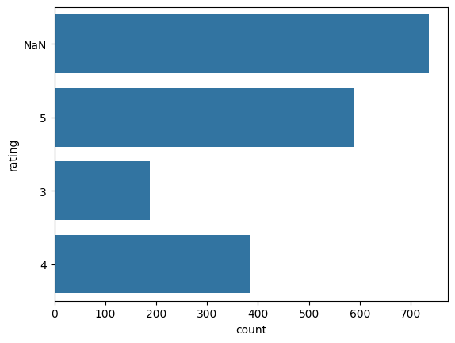

```python
sns.countplot(data = data.rating.fillna('NaN'))
plt.show()
```

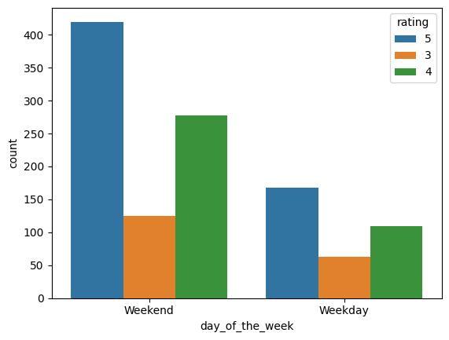

```python
#rating count based on the Day_of_the_week ; hue by ratings
sns.countplot(data = data , x = 'day_of_the_week' , hue = 'rating')
plt.show()
```

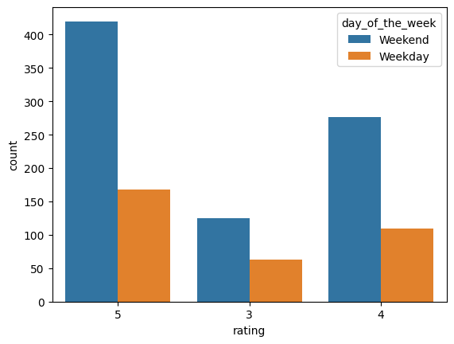

```python
#rating count hue by day of the week
sns.countplot(data = data , x = 'rating' , hue = 'day_of_the_week')
plt.show()
```

Observations:

- There are more customers ordering on weekend (Saturday and Sunday) than weekdays. Also weekend has higher rating count than weekday.
- Most of the crowd has ratings of 5 , 4 or 3.
- There were around - 736 records with No rating, 588 records with rating as 5, 386 records with rating as 4, 188 records with rating as 3,

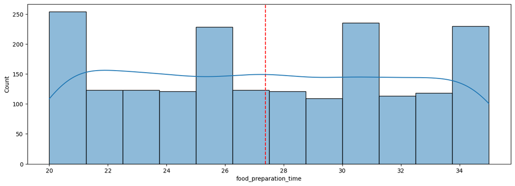

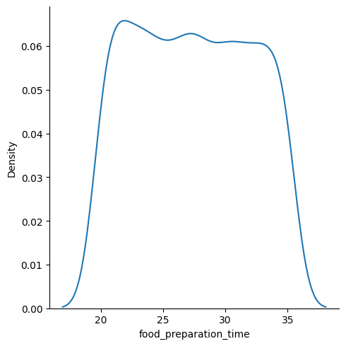

```python
#Histplot for the food_preparation_time
plt.figure(figsize = (15,5))
plt.axvline(x = data['food_preparation_time'].mean() , color = 'r' , linestyle = '--')
sns.histplot(data = data, x = 'food_preparation_time',kde = True)
sns.displot(data['food_preparation_time'] , kind = 'kde')
plt.show()
```

Observations - The food_preparation_time ranges between 20 and 35 minutes and most of the observations have food preparation time at the similar frequency . The average food preparation time is almost equal to the median food preparation time indicating a symetrical distribution.However , few of them have higher frequency of time for preparation.

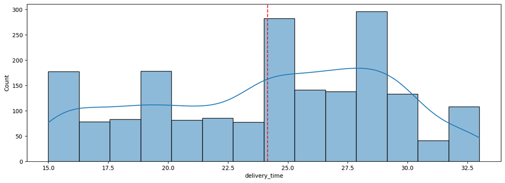

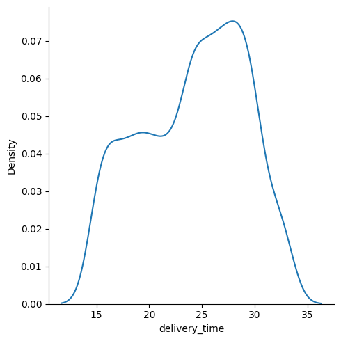

```python
#Histplot for the delivery_time
plt.figure(figsize = (15,5))
plt.axvline(x = data['delivery_time'].mean() , color = 'r' , linestyle = '--')
sns.histplot(data = data, x = 'delivery_time', kde = True)
sns.displot(data['delivery_time'] , kind = 'kde')
plt.show()
```

Observations -

- The delivery_time has time ranges between 15 and 33 minutes. It also shows a multi modal distribution.
- There are more number of orders that have delivery_time between 24 and 30 minutes.

### **Question 7**: Which are the top 5 restaurants in terms of the number of orders received? [1 mark]

```python
# top5 restaurants with the number of orders received
data['restaurant_name'].value_counts()[:5]
#data['restaurant_name'].value_counts()[:5].plot(kind = 'bar')
```

| restaurant_name | count |
| --- | --- |
| Shake Shack | 219 |
| The Meatball Shop | 132 |
| Blue Ribbon Sushi | 119 |
| Blue Ribbon Fried Chicken | 96 |
| Parm | 68 |

**dtype:** int64

#### Observations: The top 5 restaurants with high number of orders received - *'Shake Shack' , 'The Meatball Shop' , 'Blue Ribbon Sushi' , 'Blue Ribbon Fried Chicken' , 'Parm'*

### **Question 8**: Which is the most popular cuisine on weekends? [1 mark]

```python
# Most popular Cuisine on weekends
df_weekend = data[data['day_of_the_week'] == 'Weekend']
df_weekend['cuisine_type'].value_counts()[:1]
```

| cuisine_type | count |
| --- | --- |
| American | 415 |

**dtype:** int64

#### Observations: The most popular cuisine_type on weekends is American.

### **Question 9**: What percentage of the orders cost more than 20 dollars? [2 marks]

```python
# Percentage of orders above 20 dollars
df_above_20 = data[data['cost_of_the_order'] >20].cost_of_the_order.count()
print(f'Total Number of orders Placed : {Unique_OrderID}')
print(f'Total count of orders above $20 : {df_above_20}')
percentage = (df_above_20/Unique_OrderID)*100
print(f'Percentage of orders above $20 : {percentage}')
```

```
Total Number of orders Placed : 1898
Total count of orders above $20 : 555
Percentage of orders above $20 : 29.24130663856691
```

#### Observations: There are a total of 1898 orders out of which 555 orders cost above 20 dollars. The percentage of the orders above 20 dollars is 29.24 %

### **Question 10**: What is the mean order delivery time? [1 mark]

```python
# mean order delivery time
print('The mean order delivery time is:' , data['delivery_time'].mean(), 'minutes')
```

```
The mean order delivery time is: 24.161749209694417 minutes
```

#### Observations: The mean order delivery time is 24.16 minutes

### **Question 11:** The company has decided to give 20% discount vouchers to the top 3 most frequent customers. Find the IDs of these customers and the number of orders they placed. [1 mark]

```python
# Top 3 customer ID and count of orders placed
top_3_customers = data['customer_id'].value_counts()[:3]
top_3_customers
```

| customer_id | count |
| --- | --- |
| 52832 | 13 |
| 47440 | 10 |
| 83287 | 9 |

**dtype:** int64

#### Observations: The top 3 customer ID and count of orders placed -

- customer_id : 52832 with 13 orders
- customer_id : 47440 with 10 orders
- customer_id : 83287 with 9 orders

### **Question 12**: Perform a multivariate analysis to explore relationships between the important variables in the dataset. (It is a good idea to explore relations between numerical variables as well as relations between numerical and categorical variables) [10 marks]

```python
# top 5 records to display
data.head()
```

|  | order_id | customer_id | restaurant_name | cuisine_type | cost_of_the_order | day_of_the_week | rating | food_preparation_time | delivery_time |
| --- | --- | --- | --- | --- | --- | --- | --- | --- | --- |
| 0 | 1477147 | 337525 | Hangawi | Korean | 30.75 | Weekend | NaN | 25 | 20 |
| 1 | 1477685 | 358141 | Blue Ribbon Sushi Izakaya | Japanese | 12.08 | Weekend | NaN | 25 | 23 |
| 2 | 1477070 | 66393 | Cafe Habana | Mexican | 12.23 | Weekday | 5 | 23 | 28 |
| 3 | 1477334 | 106968 | Blue Ribbon Fried Chicken | American | 29.20 | Weekend | 3 | 25 | 15 |
| 4 | 1478249 | 76942 | Dirty Bird to Go | American | 11.59 | Weekday | 4 | 25 | 24 |

```python
#Relationship between cuisine_type and cost_of_the_order
data.groupby('cuisine_type')['cost_of_the_order'].mean().sort_values(ascending = False)
```

| cuisine_type | cost_of_the_order |
| --- | --- |
| French | 19.793889 |
| Southern | 19.300588 |
| Thai | 19.207895 |
| Spanish | 18.994167 |
| Middle Eastern | 18.820612 |
| Mexican | 16.933117 |
| Indian | 16.919726 |
| Italian | 16.418691 |
| American | 16.319829 |
| Chinese | 16.305209 |
| Japanese | 16.304532 |
| Mediterranean | 15.474783 |
| Korean | 14.001538 |
| Vietnamese | 12.882857 |

**dtype:** float64

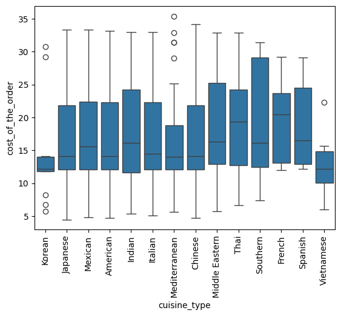

```python
#Relationship between cuisine_type and cost_of_the_order
sns.boxplot(data = data , x = 'cuisine_type' , y = 'cost_of_the_order')
plt.xticks(rotation = 90)
plt.show()
```

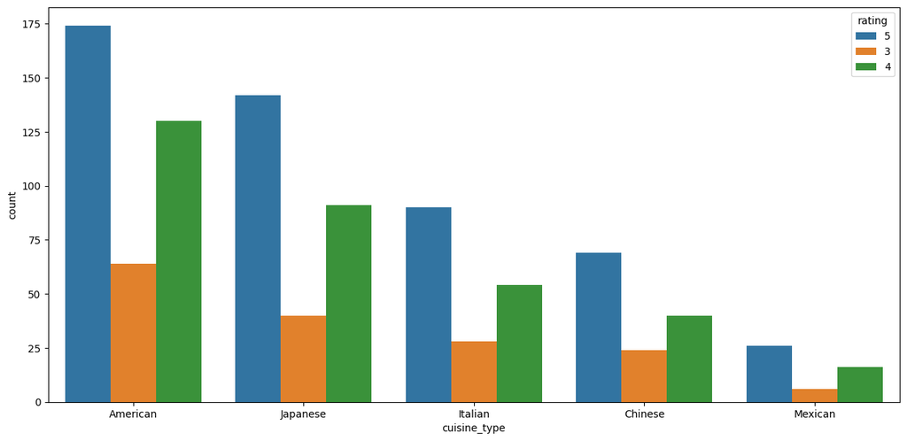

```python
plt.figure(figsize = (15,7))
sns.countplot(data = data , x = 'cuisine_type' , hue = 'rating' , order = data['cuisine_type'].value_counts().iloc[:5].index)
```

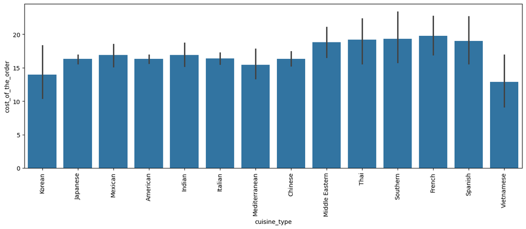

```python
plt.figure(figsize = (15,5))
sns.barplot(data = data , x = 'cuisine_type' , y = 'cost_of_the_order')
plt.xticks(rotation = 90)
plt.show()
```

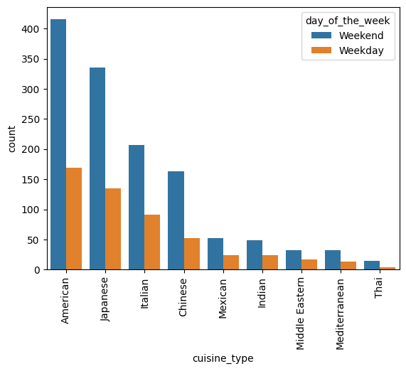

```python
# cuisine type and day of the week
sns.countplot(data = data , x = 'cuisine_type' , hue = 'day_of_the_week' , order = data['cuisine_type'].value_counts().iloc[:9].index)
plt.xticks(rotation = 90)
plt.show()
```

Observations -

- Vietnamese cuisine cost less and French cuisine cost more among the other cusines in the dataset.
- There are few outliers for the Korean , Mediterranean and Vietnamese cuisines.
- American , Japanese , Italian and Chinese are top 4 highly rated cuisines.
- Day of the week doesn't impact the selection of the cuisine.

```python
data.groupby('cuisine_type')['food_preparation_time'].mean().sort_values(ascending = False)
```

| cuisine_type | food_preparation_time |
| --- | --- |
| Southern | 27.588235 |
| Chinese | 27.511628 |
| Japanese | 27.510638 |
| Italian | 27.483221 |
| American | 27.440068 |
| Thai | 27.315789 |
| Indian | 27.109589 |
| Mediterranean | 27.000000 |
| Spanish | 26.916667 |
| French | 26.888889 |
| Mexican | 26.727273 |
| Middle Eastern | 26.673469 |
| Vietnamese | 25.714286 |
| Korean | 25.461538 |

**dtype:** float64

Observations - Food Preparation time is consistent for most of the cuisines with korean cusine taking less time.

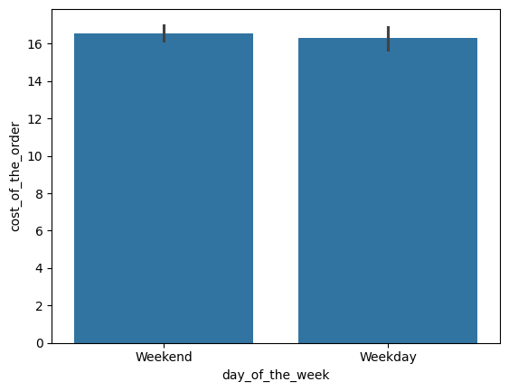

```python
#cost of the order and day of the week

sns.barplot(data = data , x = 'day_of_the_week' , y = 'cost_of_the_order')
plt.show()
```

```python
data.groupby(['rating'])['cost_of_the_order'].mean()
```

| rating | cost_of_the_order |
| --- | --- |
| 3 | 16.223351 |
| 4 | 16.710337 |
| 5 | 16.965697 |

**dtype:** float64

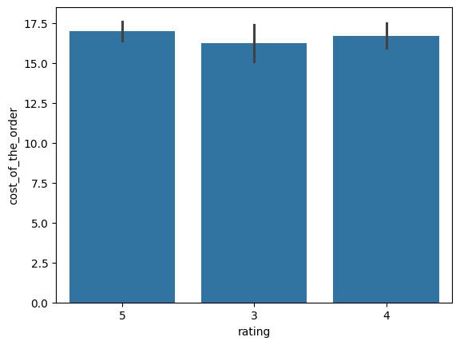

```python
sns.barplot(data = data , x = 'rating' , y = 'cost_of_the_order')
plt.show()
```

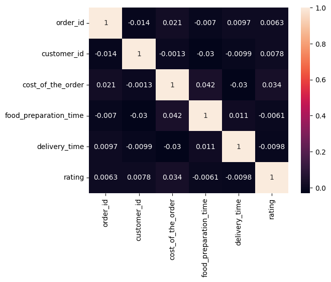

```python
#Heatmap for more relationship between fields
cols = ['order_id' , 'customer_id' , 'cost_of_the_order' , 'food_preparation_time' , 'delivery_time','rating']
sns.heatmap(data[cols].corr() , annot = True)
plt.show()
```

### **Question 13:** The company wants to provide a promotional offer in the advertisement of the restaurants. The condition to get the offer is that the restaurants must have a rating count of more than 50 and the average rating should be greater than 4. Find the restaurants fulfilling the criteria to get the promotional offer. [3 marks]

```python
#df_rating = data[data['rating'].astype('float').notna()]
df_rating = data[data['rating'].astype(str).str.isnumeric()]
# restaurants name with rating count
df_rating_count = df_rating.groupby('restaurant_name')['rating'].count().sort_values(ascending = False).reset_index()
#restaurants name with rating count greater than 50
df_restaurants = df_rating_count[df_rating_count['rating'] > 50]['restaurant_name']
#Dataframe with restaurants rating count greater than 50
df_restaurants_50 = df_rating[df_rating['restaurant_name'].isin(df_restaurants)].copy()
#converting rating column to numeric before calculating the mean
df_restaurants_50['rating'] = pd.to_numeric(df_restaurants_50['rating'])
df_restaurants_50.groupby(df_restaurants_50['restaurant_name'])['rating'].mean().sort_values(ascending = False).reset_index()
```

|  | restaurant_name | rating |
| --- | --- | --- |
| 0 | The Meatball Shop | 4.511905 |
| 1 | Blue Ribbon Fried Chicken | 4.328125 |
| 2 | Shake Shack | 4.278195 |
| 3 | Blue Ribbon Sushi | 4.219178 |

#### Observations: The restaurants having rating count greater than 50 and also with the mean rating value grater than 4 are : *'The Meatball Shop' , 'Blue Ribbon Fried Chicken', 'Shake Shack' and 'Blue Ribbon Sushi'*

### **Question 14:** The company charges the restaurant 25% on the orders having cost greater than 20 dollars and 15% on the orders having cost greater than 5 dollars. Find the net revenue generated by the company across all orders. [3 marks]

```python
# Net revenue generated by company based on the charges imposed on the orders
data['Revenue'] = data.cost_of_the_order.apply(lambda x : x*0.25 if x > 20 else x*0.15 if x > 5 else 0)
Net_revenue = data['Revenue'].sum()
print(f'The net revenue generated by the company across all orders is : {Net_revenue}')
```

```
The net revenue generated by the company across all orders is : 6166.303
```

#### Observations: The Net Revenue generated by company on all the orders is 6166.303 dollars

### **Question 15:** The company wants to analyze the total time required to deliver the food. What percentage of orders take more than 60 minutes to get delivered from the time the order is placed? (The food has to be prepared and then delivered.) [2 marks]

```python
# Percentage orders with more than 60 mins to get delivered from the time order placed
data['Total_time'] = data['food_preparation_time'] + data['delivery_time']
delivery_greater_60 = data[data['Total_time'] > 60].Total_time.count()
Total_deliveryTime = data['Total_time'].count()
print(f'Total time of orders Placed : {Total_deliveryTime}')
print(f'Total time of orders above 60 mins : {delivery_greater_60}')
percentage = (delivery_greater_60/Total_deliveryTime)*100
print(f'Percentage of orders above 60 mins : {percentage}')
```

```
Total time of orders Placed : 1898
Total time of orders above 60 mins : 200
Percentage of orders above 60 mins : 10.537407797681771
```

#### Observations:Percentage of the total orders having greater than 60 minutes of delivery time from the point the order placed is **10.54 %**

### **Question 16:** The company wants to analyze the delivery time of the orders on weekdays and weekends. How does the mean delivery time vary during weekdays and weekends? [2 marks]

```python
# mean delivery time on weekdays
df_weekday = data[data['day_of_the_week'] == 'Weekday']['delivery_time'].mean()
print(f'The mean delivery time on weekdays is : {df_weekday}')

df_weekend = data[data['day_of_the_week'] == 'Weekend']['delivery_time'].mean()
print(f'The mean delivery time on weekends is : {df_weekend}')
```

```
The mean delivery time on weekdays is : 28.340036563071298
The mean delivery time on weekends is : 22.4700222057735
```

#### Observations:

- The mean delivery time on Weekdays is : 28.34 mins
- The mean delivery time on Weekend is : 22.47 mins

The weeday deliveries take longer time than the weekends likely due to traffic flow on weekdays.

### Recommendations:

- FoodHub should make some efforts in understanding the customers who ordered less than 3 times. They should focus on these customers on what made them to not order more often.
- FoodHub should investigate the reason for low rating count.They should attract customers to provide ratings by giving some discounts or special entry prize coupons.
- FoodHub should invest in infrastructure to reduce delivery times , enhance customer satisfaction by encouraging restaurants to shorten food preparation time and also they should focus on promoting trending cuisines to drive growth.